Saltar al contenido principal

# Diseño experimental y libro de campo con Tarpuy

Germinación de quinua (*Chenopodium quinoa*) bajo estrés salino

Autor/a

Bryan Chávez Velaisosa

Fecha de publicación

6 de noviembre de 2026

# 1 Introducción

**Tarpuy** (“sembrar” en quechua) es el módulo del paquete `inti` (Lozano-Isla) para **planificar experimentos**: genera el diseño aleatorizado, el libro de campo (*fieldbook*) con códigos para cada unidad experimental y el croquis.

En este trabajo se planifica un experimento de germinación de quinua bajo distintas concentraciones de NaCl.

# 2 Paquetes

**Código**

```r
# Instalar una sola vez (ver README):
# install.packages(c("remotes", "tidyverse", "writexl"))
# remotes::install_github("flavjack/inti")

library(inti)
library(tidyverse)
library(writexl)
```

# 3 Planteamiento del experimento

| Elemento | Descripción |
| --- | --- |
| Objetivo | Evaluar el efecto de la salinidad (NaCl) sobre la germinación de tres variedades de quinua |
| Factor A | Salinidad: 0, 50, 100 y 150 mM de NaCl |
| Factor B | Variedad: Blanca de Juli, Salcedo INIA, Pasankalla |
| Tratamientos | 4 × 3 = 12 combinaciones |
| Diseño | Completamente al azar (DCA) con arreglo factorial 4 × 3 |
| Repeticiones | 4 |
| Unidad experimental | Placa Petri con 25 semillas |
| Total de unidades | 12 × 4 = 48 placas |
| Lugar | Laboratorio, UNTRM – Chachapoyas |

Se usa DCA porque en laboratorio las condiciones (temperatura, luz) son homogéneas; no hay un gradiente que justifique bloques.

**Modelo aditivo lineal:**

$$Y_{ijk} = \mu + \alpha_i + \beta_j + (\alpha\beta)_{ij} + \varepsilon_{ijk}$$

donde $\alpha_i$ es el efecto de la salinidad, $\beta_j$ el de la variedad, $(\alpha\beta)_{ij}$ la interacción y $\varepsilon_{ijk}$ el error experimental.

# 4 Factores y niveles

Tarpuy recibe una tabla donde **cada columna es un factor** y sus filas son los niveles. Si un factor tiene menos niveles, se completa con `NA`.

**Código**

```r
factores <- data.frame(
  salinidad = c("0mM", "50mM", "100mM", "150mM"),
  variedad  = c("Blanca de Juli", "Salcedo INIA", "Pasankalla", NA)
)

factores
```

```
  salinidad       variedad
1       0mM Blanca de Juli
2      50mM   Salcedo INIA
3     100mM     Pasankalla
4     150mM           <NA>
```

# 5 Diseño aleatorizado con `tarpuy_design()`

**Código**

```r
fb <- tarpuy_design(
  data     = factores,
  nfactors = 2,        # número de factores
  type     = "crd",    # DCA (completely randomized design)
  rep      = 4,        # repeticiones
  serie    = 100,      # numeración de placas: 101, 102, ...
  seed     = 2026,     # semilla: hace la aleatorización reproducible
  project  = "QSAL"    # prefijo del código QR / etiqueta
)

nrow(fb)   # deben ser 48 unidades
```

```
[1] 48
```

**Código**

```r
head(fb, 10)
```

```
# A tibble: 10 × 10
   qrcode   plots ntreat salinidad variedad        sort   rep  rows  cols design
   <chr>    <int>  <int> <chr>     <chr>          <int> <int> <int> <int> <chr>
 1 QSAL_101   101      9 0mM       Pasankalla         1     4     1     1 crd
 2 QSAL_102   102      6 50mM      Salcedo INIA       2     3     1     2 crd
 3 QSAL_103   103     10 50mM      Pasankalla         3     2     1     3 crd
 4 QSAL_104   104      3 100mM     Blanca de Juli     4     3     1     4 crd
 5 QSAL_105   105      7 100mM     Salcedo INIA       5     1     1     5 crd
 6 QSAL_106   106      5 0mM       Salcedo INIA       6     4     1     6 crd
 7 QSAL_107   107      3 100mM     Blanca de Juli     7     4     1     7 crd
 8 QSAL_108   108      4 150mM     Blanca de Juli     8     3     1     8 crd
 9 QSAL_109   109      8 150mM     Salcedo INIA       9     3     1     9 crd
10 QSAL_110   110      2 50mM      Blanca de Juli    10     2     1    10 crd
```

Columnas principales:

- `qrcode`: código único de cada placa (sirve para las etiquetas).
- `plots`: número de la unidad experimental.
- `ntreat`: número del tratamiento (1 a 12).
- `rep`: repetición.
- `rows` y `cols`: ubicación física en la mesa del laboratorio.

## 5.1 Verificación del balance

Cada combinación salinidad × variedad debe aparecer exactamente 4 veces:

**Código**

```r
fb |> count(salinidad, variedad) |>
  pivot_wider(names_from = variedad, values_from = n)
```

```
# A tibble: 4 × 4
  salinidad `Blanca de Juli` Pasankalla `Salcedo INIA`
  <chr>                <int>      <int>          <int>
1 0mM                      4          4              4
2 100mM                    4          4              4
3 150mM                    4          4              4
4 50mM                     4          4              4
```

# 6 Croquis del experimento

**Código**

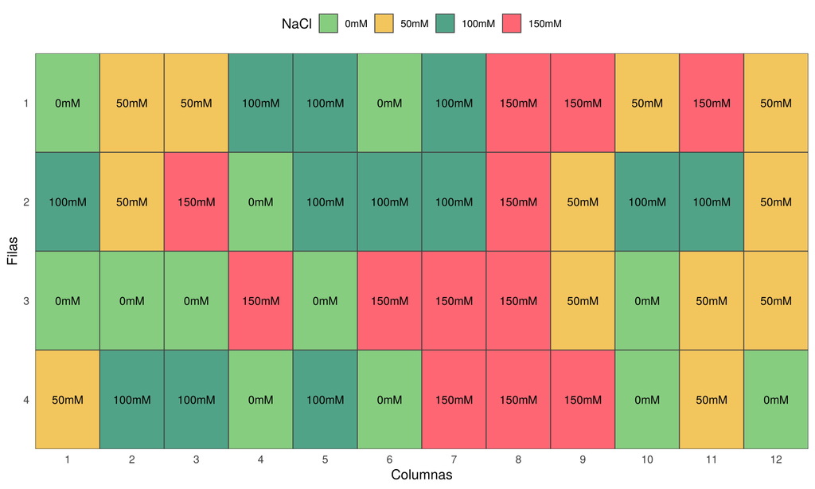

Figura 1: Croquis de la distribución aleatoria de las 48 placas Petri

```r
croquis <- fb |>
  mutate(salinidad = factor(salinidad, levels = factores$salinidad)) |>
  tarpuy_plotdesign(fill = "salinidad", xlab = "Columnas", ylab = "Filas",
                    glab = "NaCl", font_family = "sans")
croquis
```

# 7 Libro de campo con variables a evaluar

Se agregan las columnas que se llenarán durante el ensayo: el número de semillas germinadas cada día (conteo acumulado, día 1 al 7) y la longitud de radícula al día 7.

**Código**

```r
dias <- paste0("germ_d", 1:7)          # germ_d1 ... germ_d7

libro <- fb |>
  mutate(semillas = 25) |>
  select(qrcode, plots, ntreat, rep, salinidad, variedad,
         rows, cols, semillas) |>
  bind_cols(
    as_tibble(setNames(rep(list(NA_real_), length(dias)), dias))
  ) |>
  mutate(radicula_mm_d7 = NA_real_,
         observaciones  = NA_character_)

head(libro)
```

```
# A tibble: 6 × 18
  qrcode   plots ntreat   rep salinidad variedad     rows  cols semillas germ_d1
  <chr>    <int>  <int> <int> <chr>     <chr>       <int> <int>    <dbl>   <dbl>
1 QSAL_101   101      9     4 0mM       Pasankalla      1     1       25      NA
2 QSAL_102   102      6     3 50mM      Salcedo IN…     1     2       25      NA
3 QSAL_103   103     10     2 50mM      Pasankalla      1     3       25      NA
4 QSAL_104   104      3     3 100mM     Blanca de …     1     4       25      NA
5 QSAL_105   105      7     1 100mM     Salcedo IN…     1     5       25      NA
6 QSAL_106   106      5     4 0mM       Salcedo IN…     1     6       25      NA
# ℹ 8 more variables: germ_d2 <dbl>, germ_d3 <dbl>, germ_d4 <dbl>,
#   germ_d5 <dbl>, germ_d6 <dbl>, germ_d7 <dbl>, radicula_mm_d7 <dbl>,
#   observaciones <chr>
```

## 7.1 Variables que se calcularán con los datos

| Variable | Fórmula |
| --- | --- |
| Porcentaje de germinación (PG) | (germinadas al día 7 / 25) × 100 |
| Velocidad de germinación (IVG) | Σ (nᵢ / tᵢ) |
| Tiempo medio de germinación (TMG) | Σ (nᵢ · tᵢ) / Σ nᵢ |
| Longitud de radícula | medición directa (mm) |

Estas variables se pueden calcular después con el paquete **GerminaR** (también del Dr. Lozano-Isla).

# 8 Exportar a Excel

**Código**

```r
dir.create("salidas", showWarnings = FALSE)

write_xlsx(
  list(
    libro_campo = libro,
    factores    = factores,
    diseno      = fb
  ),
  path = "salidas/libro_campo_quinua_salinidad.xlsx"
)

ggsave("salidas/croquis.png", croquis, width = 10, height = 6, dpi = 300)
```

El archivo `salidas/libro_campo_quinua_salinidad.xlsx` se imprime y se usa en el laboratorio. La columna `qrcode` sirve para hacer las etiquetas de cada placa.

# 9 Alternativa: la app Tarpuy

Lo mismo se puede hacer con la interfaz gráfica, conectada a Google Sheets:

**Código**

```r
inti::tarpuy()
```

# 10 Referencias

Lozano-Isla, F. (2024). *inti: Tools and Statistical Procedures in Plant Science*. R package. https://inkaverse.com